# CH08P65 Two Way ANOVA

crl

May 28, 2018

```r
knitr::opts_chunk$set(echo = TRUE)
```

# QCI Six Sigma Primer

## Two Way ANOVA

### Overview

*Two Way ANOVA* is used to compare means for three or more groups for two different factors.

- See One Way ANOVA.

*Factor* is a variable that is thought to influence the outcome of the response.

- machine; material; temperature

*Treatment* is a level or value of a factor.

- machine A or B; material 1 or 2; temperature high or low

### Read More

[Two Way ANOVA Wikipedia](https://en.wikipedia.org/wiki/Two-way_analysis_of_variance)

[Two Way ANOVA NIST](https://en.wikipedia.org/wiki/Two-way_analysis_of_variance)

[Examples here](http://www.sthda.com/english/wiki/two-way-anova-test-in-r)

[ANOVA assumptions STHDA](http://www.sthda.com/english/wiki/one-way-anova-test-in-r#check-anova-assumptions-test-validity)

[ANOVA assumptions Quick R](https://www.statmethods.net/stats/anovaAssumptions.html)

### More

[Presentation](https://docs.google.com/presentation/d/1W4IdxwG_raXJ_NotgdwgyplsfShOQqOzJYarinLmMXw/edit?usp=sharing)

[Variance Partitioning](https://drive.google.com/file/d/1_JmnMcrZqlPW4glg7GvGE0u4b9Uwn0kK/view?usp=sharing)

### ANOVA Hypotheses

The null hypothesis H0 is that there is no difference between any of the sample means for each factor.  
The alternate hypothesis HA is that there is a difference between at least two of the sample means.

# Analysis

## Load Packages

```r
library(tidyverse)
library(car)
library(lmtest)
library(vrtest)
```

## Primer Example

### Prepare the data set.

Often we use stringsAsFactors = FALSE.  
In this case, with ANOVA, the categorical (explanatory) variables should be factors, therefore we use the default stringsAsFactors = TRUE.

```r
dat <- read.csv('data/ch08p65-two-way-anova.csv')
glimpse(dat)
```

```
## Observations: 18
## Variables: 3
## $ instructor <fct> inst1, inst1, inst1, inst1, inst1, inst1, inst1, in...
## $ material   <fct> m1, m1, m1, m2, m2, m2, m3, m3, m3, m1, m1, m1, m2,...
## $ result     <int> 88, 84, 92, 68, 62, 72, 76, 70, 78, 60, 68, 58, 44,...
```

## Look at the data

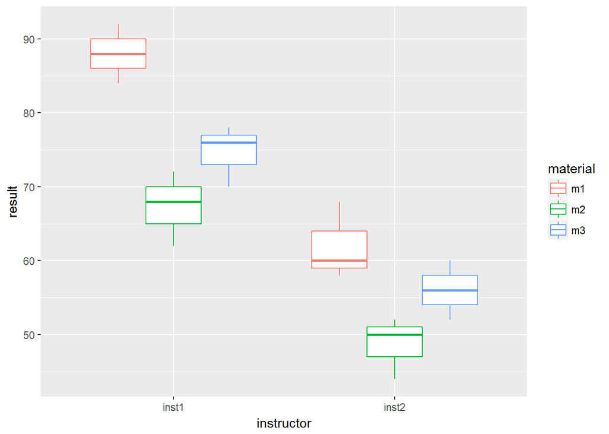

```r
ggplot(data = dat, aes(x = instructor, y = result, color = material)) +
  geom_boxplot()
```

From just a boxplot it is not always easy to know if sample means are different.  
This is why we also use ANOVA.

## Two Way (Main) ANOVA

### Conducting the ANOVA analysis

```r
fit <- aov(result ~ material + instructor, data = dat)
summary(fit)
```

```
##             Df Sum Sq Mean Sq F value   Pr(>F)
## material     2  872.4   436.2   20.79 6.44e-05 ***
## instructor   1 2005.6  2005.6   95.58 1.24e-07 ***
## Residuals   14  293.8    21.0
## ---
## Signif. codes:  0 '***' 0.001 '**' 0.01 '*' 0.05 '.' 0.1 ' ' 1
```

Comparing results to the Primer:

- SST “material” matches the R output (872.4)
- SST “instructor” matches the R output (2005.6)
- SSE matches the R output (293.8)
- F value for “material” matches the R output (20.8)
- F value for “instructor” matches the R output (95.6)
- Degrees of Freedom match the R output (2, 1, 14)

MATERIAL  
The critical value of F with df = (2, 14) at alpha = 0.05 is 3.74  
The calculated value of F (20.8) is larger than F critical.  
Therefore we reject H0 that there is no difference between any of the sample means for material.

INSTRUCTOR  
The critical value of F with df = (1, 14) at alpha = 0.05 is 4.60  
The calculated value of F (95.6) is larger than F critical.  
Therefore we reject H0 that there is no difference between any of the sample means for instructor.

### How can we find out where the differences exist?

[Stat Notes - ANOVA Post-Hoc Tests](https://drive.google.com/file/d/1hs32aXJ_Nqc0mBeE9qv1yvcTYwwfX8Bg/view?usp=sharing)

```r
TukeyHSD(fit)
```

```
##   Tukey multiple comparisons of means
##     95% family-wise confidence level
##
## Fit: aov(formula = result ~ material + instructor, data = dat)
##
## $material
##             diff         lwr        upr     p adj
## m2-m1 -17.000000 -23.9220558 -10.077944 0.0000442
## m3-m1  -9.666667 -16.5887224  -2.744611 0.0068648
## m3-m2   7.333333   0.4112776  14.255389 0.0374069
##
## $instructor
##                  diff       lwr       upr p adj
## inst2-inst1 -21.11111 -25.74263 -16.47959 1e-07
```

### Plot of means and confidence intervals

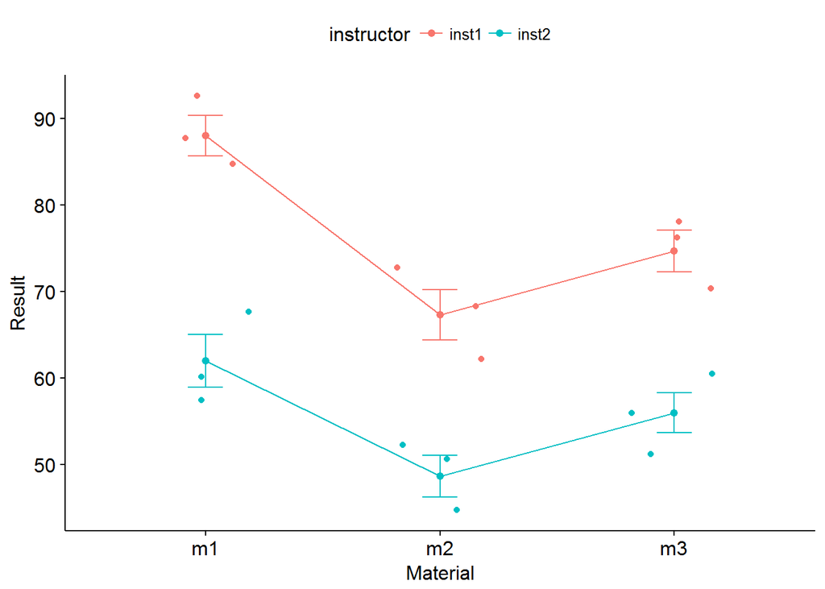

```r
# Mean plots
# Plot response by group
# Add error bars: mean_se
# (other values include: mean_sd, mean_ci, median_iqr, ....)
library(ggpubr)
ggline(dat, x = "material", y = "result",
       add = c("mean_se", "jitter"),
       ylab = "Result", xlab = "Material",
       color = 'instructor')
```

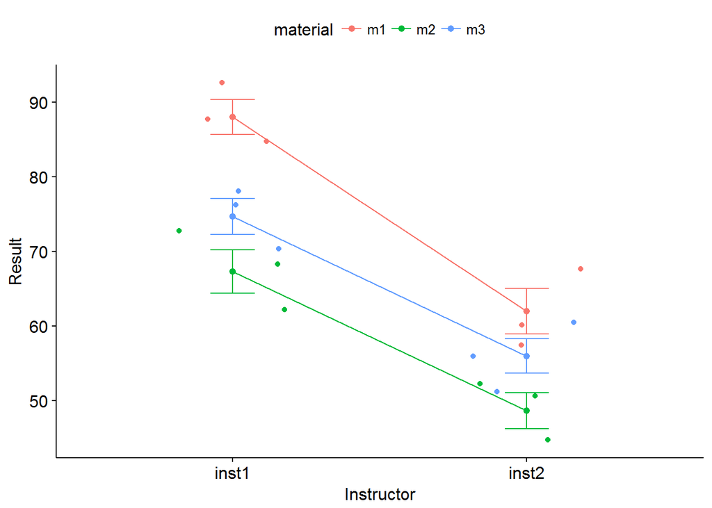

```r
# Mean plots
# Plot weight by group
# Add error bars: mean_se
# (other values include: mean_sd, mean_ci, median_iqr, ....)
library(ggpubr)
ggline(dat, x = "instructor", y = "result",
       add = c("mean_se", "jitter"),
       ylab = "Result", xlab = "Instructor",
       color = 'material')
```

## Model Diagnostics

Testing the assumptions behind the ANOVA method.

### Plot fitted vs residuals

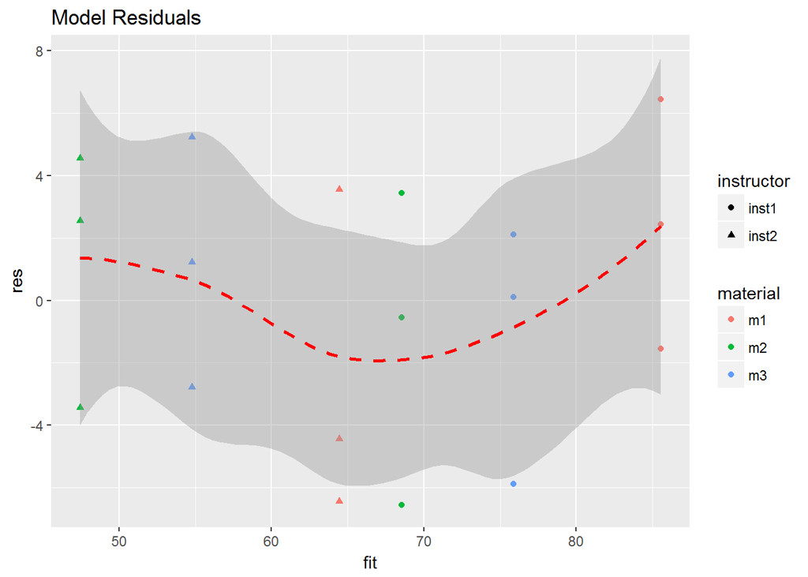

```r
# plot residuals vs fitted

# OLD CODE
# fitted.y <- fit$fitted
# plot(fitted.y, residuals(fit))
# title("Residuals vs Fitted Values")
# grid()

# NEW CODE
tmp_res <- residuals(fit)
tmp_stres <- rstudent(fit)

dat1 <- dat %>%
  mutate(fit = fitted(fit)) %>%
  mutate(res = tmp_res) %>%
  mutate(stres = tmp_stres)

ggplot(dat1, aes(x = fit, y = res)) +
  geom_point(aes(color = material, shape = instructor)) +
  geom_smooth(method = 'loess', span = 0.75, color = 'red', linetype = 2) +
  ggtitle('Model Residuals')
```

### Plot residuals vs factor 1 (material)

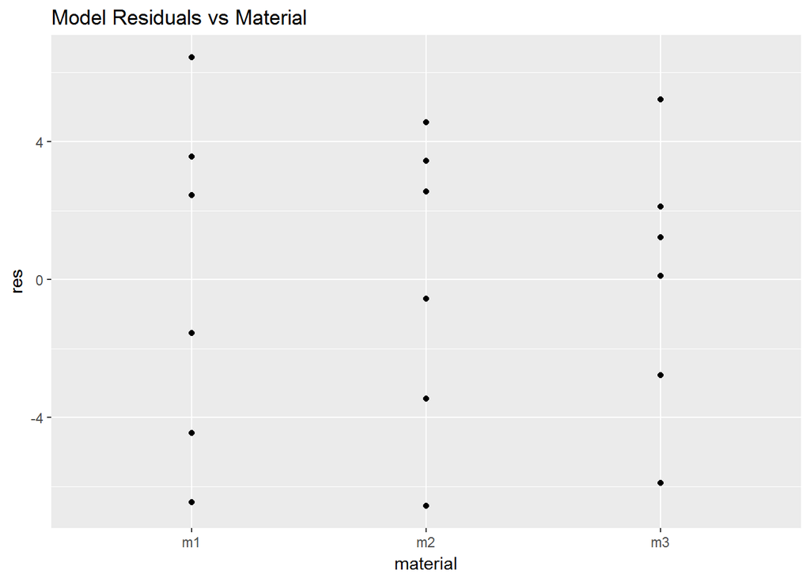

```r
ggplot(dat1, aes(x = material, y = res)) +
  geom_point() +
  ggtitle('Model Residuals vs Material')
```

### Plot residuals vs factor 2 (instructor)

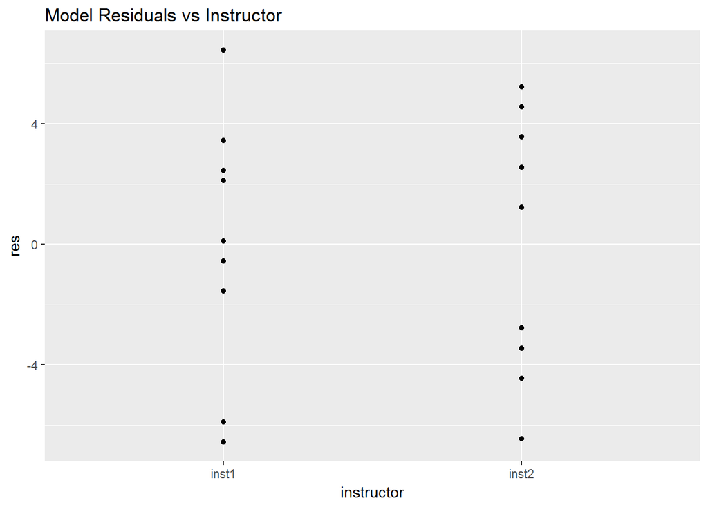

```r
ggplot(dat1, aes(x = instructor, y = res)) +
  geom_point() +
  ggtitle('Model Residuals vs Instructor')
```

### Normality diagnostics

Test normality using Shapiro-Wilks test

```r
res.shapiro = shapiro.test(residuals(fit))

print(res.shapiro)
```

```
##
##  Shapiro-Wilk normality test
##
## data:  residuals(fit)
## W = 0.94372, p-value = 0.3351
```

```r
if (res.shapiro$p.value < 0.05){
  print("Nonnormally distributed residuals")} else {
    print("Normally distributed residuals")
  }
```

```
## [1] "Normally distributed residuals"
```

Normality plot of residuals

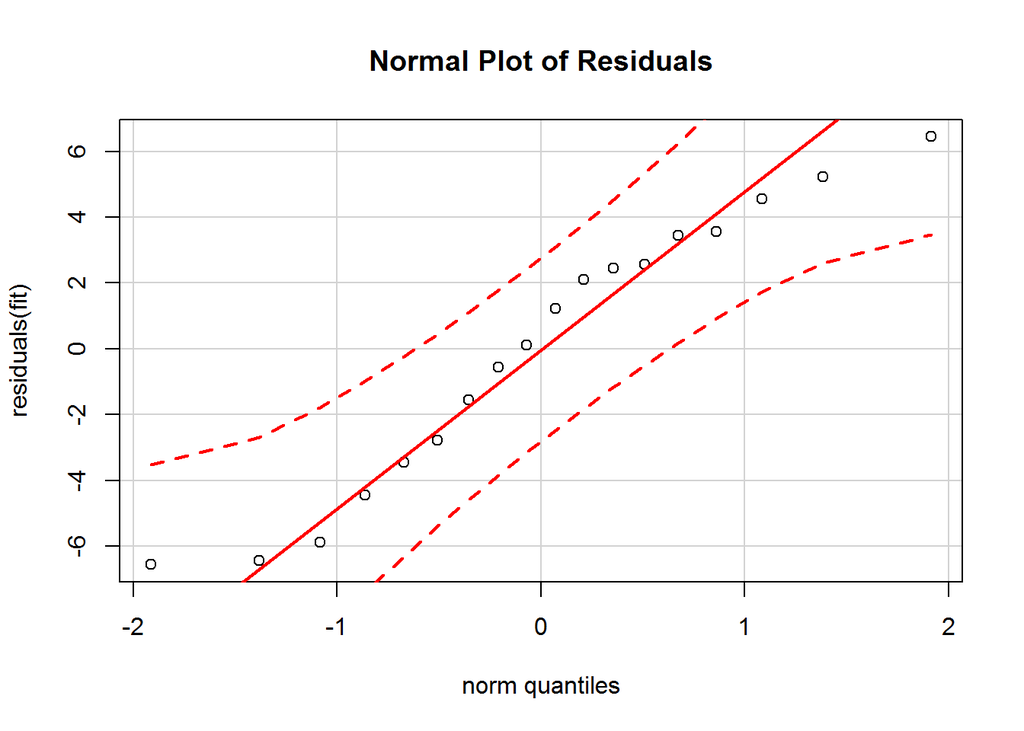

```r
qqPlot(residuals(fit), main = "Normal Plot of Residuals")
```

### Family of influence measures

```r
infl.fit = influence.measures(fit)

print(summary(infl.fit))
```

```
## Potentially influential observations of
##   aov(formula = result ~ material + instructor, data = dat) :
## NONE
## numeric(0)
```

```r
id.infl = which(apply(infl.fit$is.inf, 1, any))

print("Most influential observations:")
```

```
## [1] "Most influential observations:"
```

```r
print(id.infl)
```

```
## named integer(0)
```

### Cook’s Distance

```r
# find unusual Cooks Distance

fit.cook = cooks.distance(fit)

print("Influential Cooks D")
```

```
## [1] "Influential Cooks D"
```

```r
print(which(fit.cook > 3*mean(fit.cook)))
```

```
## named integer(0)
```

### Plot Cook’s diagnostics

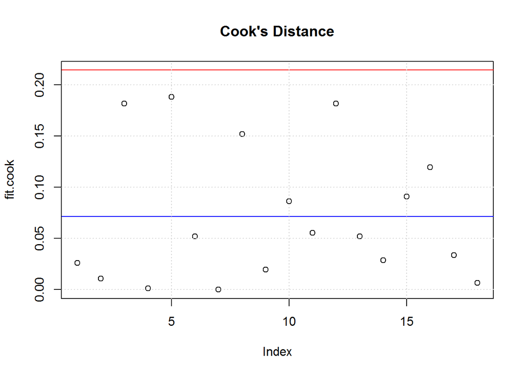

```r
fit.cook = cooks.distance(fit)

id.c = which(fit.cook > 3*mean(fit.cook))

# plot Cooks Distance
cymax <- 3*mean(fit.cook)
plot(fit.cook, ylim = c(0, cymax))
abline(h = c(1,3)*mean(fit.cook), col = c('blue', 'red'))
title("Cook's Distance")
grid()
```

```r
if (length(id.c) > 0){ text(id.c, fit.cook[id.c], rownames(dat)[id.c], pos = 2, xpd = TRUE) }
```

### Print studentized residuals diagnostics

```r
# STUDENTIZED RESIDUALS
fit.studres = rstudent(fit)

print("Noteworthy studentized residuals")
```

```
## [1] "Noteworthy studentized residuals"
```

```r
print(which(abs(fit.studres) > 3))
```

```
## named integer(0)
```

### Plot studentized residuals diagnostics

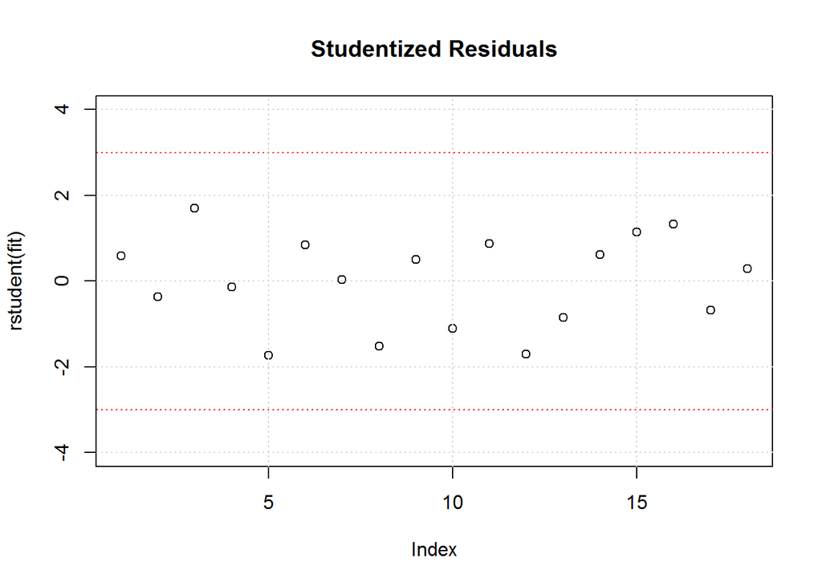

```r
fit.studres = rstudent(fit)

id.sr = which(abs(fit.studres) > 3)

# plot studentized residuals
plot(rstudent(fit), ylim = c(-4,4))
abline(h = c(-3,+3), col = 'red', lty = 3)
title('Studentized Residuals')
grid()
```

```r
if (length(id.sr) > 0){ text(id.sr, fit.studres[id.sr], rownames(dat)[id.sr], pos = 2, xpd = TRUE) }
```

### Print leverage diagnostics

```r
# LEVERAGE based on HAT MATRIX
fit.hat = hatvalues(fit)

print("Noteworthy leverage values")
```

```
## [1] "Noteworthy leverage values"
```

```r
print(which(fit.hat > 3*mean(fit.hat)))
```

```
## named integer(0)
```

### Plot leverage diagnostics

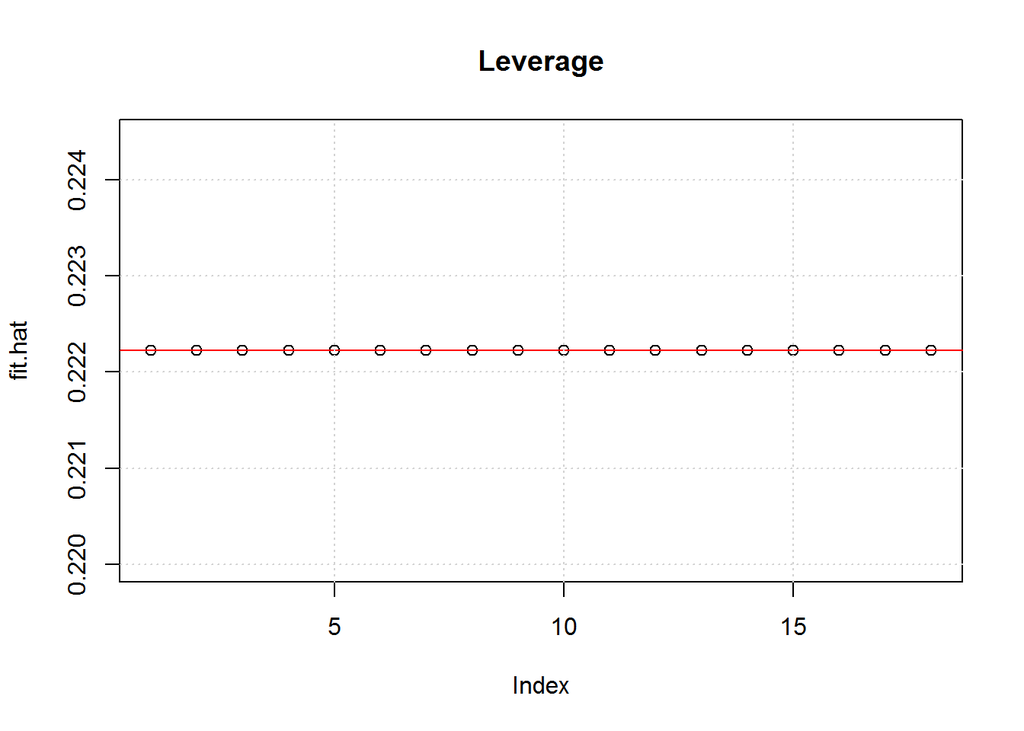

```r
fit.hat = hatvalues(fit)

id.h = which(fit.hat > 3*mean(fit.hat))


# plot leverage
plot(fit.hat)
abline(h = c(1,3)*mean(fit.hat), col = 2)
title('Leverage')
grid()
```

```r
if (length(id.h) > 0){ text(id.h, fit.hat[id.h], rownames(dat)[id.h], pos = 2, xpd = TRUE) }
```

### Print functional form diagnostics

```r
# test for functional form
# conditional mean of residuals equal to zero
# using the RESET test

res.fform = resettest(fit)

if (res.fform$p.value < 0.05){
  print("Functional Form Misspecified [E(e|X) <> 0]")} else {
    print("Functional Form Adequate [E(e|X) = 0]")
  }
```

```
## [1] "Functional Form Adequate [E(e|X) = 0]"
```

### Print constant variance (of residuals) diagnostics

```r
# test for heteroskedasticity
# using the Breusch-Pagan test

res.bp = bptest(fit)
res.bp$p.value
```

```
##        BP
## 0.8199993
```

```r
if (res.bp$p.value < 0.05){
  print("Residuals have NON-constant variance")} else {
    print("Residuals have constant variance")
  }
```

```
## [1] "Residuals have constant variance"
```

Levene’s test for equal variances for “material”

```r
leveneTest(result ~ material, data = dat)
```

```
## Levene's Test for Homogeneity of Variance (center = median)
##       Df F value Pr(>F)
## group  2  1.5963 0.2352
##       15
```

Levene’s test for equal variances for “instructor”

```r
leveneTest(result ~ instructor, data = dat)
```

```
## Levene's Test for Homogeneity of Variance (center = median)
##       Df F value Pr(>F)
## group  1  1.1579 0.2979
##       16
```

## Nonparametric alternative to Two Way ANOVA

- (main effects model; no interaction)

### Rank Transform the Response Variable

Create the rank transform of y (result)

```r
# rank transform y (result)
dat1 <- dat1 %>% mutate(rank_y = rank(result))
```

Fit the ANOVA model using the rank transform of y

```r
fit_rank <- aov(rank_y ~ material + instructor, data = dat1)
summary(fit_rank)
```

```
##             Df Sum Sq Mean Sq F value   Pr(>F)
## material     2    108    54.0   20.43 7.04e-05 ***
## instructor   1    338   338.0  127.89 2.00e-08 ***
## Residuals   14     37     2.6
## ---
## Signif. codes:  0 '***' 0.001 '**' 0.01 '*' 0.05 '.' 0.1 ' ' 1
```

Conclusion?

- We see that both main effects are significant in the model.

Why use?

- Affirms the results of ‘regular’ (parametric) ANOVA.
- Useful if model assumptions for regular ANOVA are violated.